# **Using R for Spatial Data Analysis** Israel Central Bureau of Statistics `2021-01-19`

Michael Dorman **Geography and Environmental Development** dorman@post.bgu.ac.il

# Introduction

This is an exercise and checklist to make sure that your system is correctly set up for the Using R for Spatial Data Analysis lecture.

A script with the R code of this document is available here:

https://github.com/michaeldorman/R-Spatial-Workshop-at-CBS-2021/raw/main/preparation.R

The Rmarkdown file is available here:

https://github.com/michaeldorman/R-Spatial-Workshop-at-CBS-2021/raw/main/preparation.Rmd

All of the materials are also available on [GitHub](https://github.com/michaeldorman/R-Spatial-Workshop-at-CBS-2021/).

# Setting up R environemnt

To setup the R environment:

- Install R
- Install RStudio
- In R, install the `sf` package:

```r
install.packages("sf")
```

You should now be able to load the `sf` package as follows:

```r
library(sf)
```

# Sample data

Now, download the ZIP file with sample data from:

https://github.com/michaeldorman/R-Spatial-Workshop-at-CBS-2021/raw/main/data.zip

The file contains two Shapefiles and one Geodatabase (Table 1).

Table 1: Sample data

| Data | File(s) | Format | Source |
| --- | --- | --- | --- |
| “Nafot” | `nafot.shp` (+7) | Shapefile | https://www.gov.il/he/Departments/Guides/info-gis |
| Railways | `RAIL_STRATEGIC.shp` (+7) | Shapefile | https://data.gov.il/dataset/rail_strategic |
| Statistical areas | `statisticalareas_demography2018.gdb` | GDB | https://www.cbs.gov.il/he/Pages/geo-layers.aspx |

Extract the contents of the ZIP file and set the working directory to that location using an expression such as (use your own path):

```r
setwd("C:\\Data\\CSB")
```

Alternatively, run the following expressions to automatically download and unzip the sample data into your current working directory:

```r
url = "https://github.com/michaeldorman/R-Spatial-Workshop-at-CBS-2021/raw/main/data.zip"
download.file(url, "data.zip")
unzip("data.zip")
```

# Reading the layers

If all worked well, the following expressions will import the three layers into R.

Note that the file names are prefixed with `data/` when the layers are in a sub-directory named `data`, inside the working directory.

```r
nafot = st_read("data/nafot.shp")
## Reading layer `nafot' from data source `/home/michael/Sync/Presentations/p_2021_01_LMS_Intro_to_Spatial_R/data/nafot.shp' using driver `ESRI Shapefile'
## Simple feature collection with 15 features and 1 field
## geometry type:  POLYGON
## dimension:      XY
## bbox:           xmin: 620662.1 ymin: 3263494 xmax: 770624.4 ymax: 3691834
## projected CRS:  WGS 84 / UTM zone 36N
```

```r
rail = st_read("data/RAIL_STRATEGIC.shp", options = "ENCODING=UTF-8")
## options:        ENCODING=UTF-8
## Reading layer `RAIL_STRATEGIC' from data source `/home/michael/Sync/Presentations/p_2021_01_LMS_Intro_to_Spatial_R/data/RAIL_STRATEGIC.shp' using driver `ESRI Shapefile'
## Simple feature collection with 217 features and 6 fields
## geometry type:  LINESTRING
## dimension:      XY
## bbox:           xmin: 157822.2 ymin: 385552.2 xmax: 255113.7 ymax: 790663.5
## projected CRS:  Israel 1993 / Israeli TM Grid
```

```r
stat = st_read("data/statisticalareas_demography2018.gdb", options = "ENCODING=UTF-8")
## options:        ENCODING=UTF-8
## Reading layer `statisticalareas_demography2018' from data source `/home/michael/Sync/Presentations/p_2021_01_LMS_Intro_to_Spatial_R/data/statisticalareas_demography2018.gdb' using driver `OpenFileGDB'
## Simple feature collection with 3194 features and 34 fields
## geometry type:  GEOMETRY
## dimension:      XY
## bbox:           xmin: 130175.2 ymin: 378139.7 xmax: 284068.5 ymax: 804530.3
## projected CRS:  Israel 1993 / Israeli TM Grid
```

If the files are in the working directory, use just the file name, as follows:

```r
nafot = st_read("nafot.shp")
rail = st_read("RAIL_STRATEGIC.shp")
stat = st_read("statisticalareas_demography2018.gdb")
```

# Plotting the layers

Let’s try to plot the layers (Figures 1, 2, and 3):

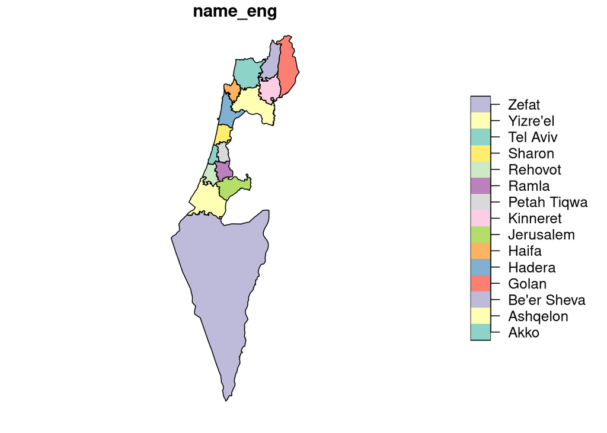

Figure 1: The `nafot` layer

```r
plot(nafot, key.width = lcm(4))
```

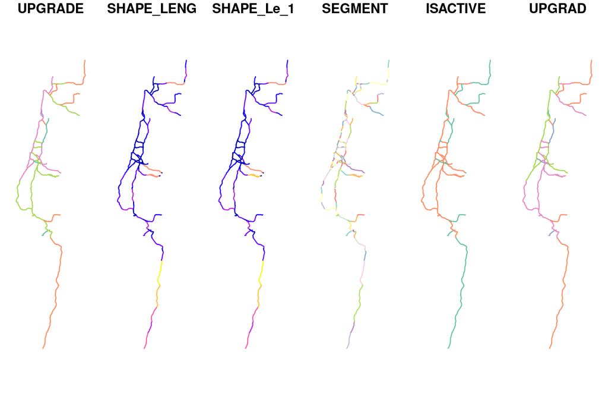

Figure 2: The `rail` layer

```r
plot(rail)
```

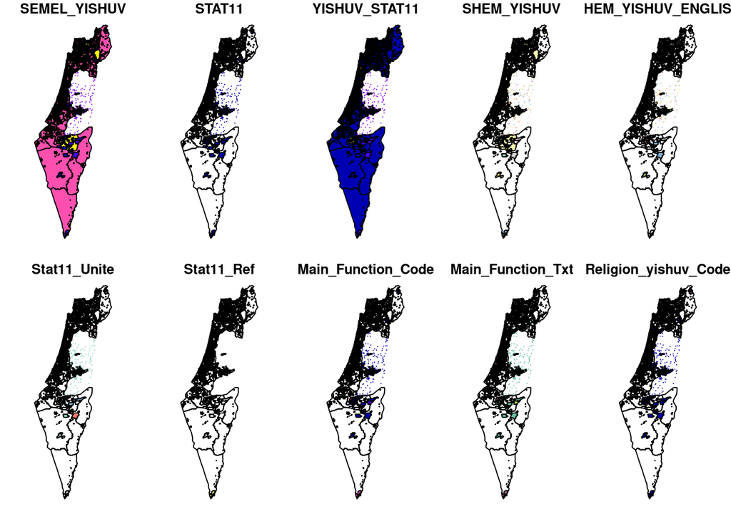

Figure 3: The `stat` layer

```r
plot(stat)
```

# Using Hebrew text in R

Finally, to make sure that we can work with Hebrew in R, try to subset the *active* railway lines with the following expression:

```r
rail = rail[rail$ISACTIVE == "פעיל", ]
```

and then plot the subset (Figure 4):

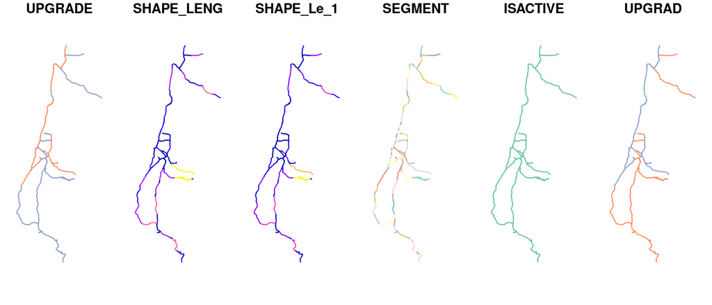

Figure 4: The `rail` layer, subset of active railway lines

```r
plot(rail)
```

In case you are working with the [R script file](https://github.com/michaeldorman/R-Spatial-Workshop-at-CBS-2021/raw/main/preparation.R) or the [Rmarkdown file](https://github.com/michaeldorman/R-Spatial-Workshop-at-CBS-2021/raw/main/preparation.Rmd), to properly display the Hebrew text the file needs to be opened with the UTF-8 encoding. To do that:

- Open the file in RStudio, by double-click or through **File→Open File…**
- Click on **File→Reopen with Encoding**
- Select **UTF-8** from the list, and click **OK** (Figure 5)

[figure not shown]

Figure 5: Reopening an R script with the UTF-8 encoding in RStudio

# Prerequisites

To follow the code examples in the lecture, you should be familiar with the following topics and aspects of the R language:

- Installing R and RStudio
- Installing and loading packages
- Working with vectors, `matrix` and `data.frame`
- Arithmetic operators (`+`, `-`, …)
- Conditional operators (`<`, `==`, …)
- Subsetting (`[`, `$`)